# Sports Car Project - Explore and Visualise Data

In this Notebook I will continue the Sports Car Project (dataset from Kaggle), moving onto exploring and visualising the cleaned dataset. The aim of this project is to:

- Preview data to ensure correct loading
- Descriptive Statistics and visualisations:
  - Single Categorical Variables: will look at the frequency counts of each category, as well as visualise this using a barchart.
  - Single Numeric Variables: will look at the central tendency (mean, median) and spread (range, IQR, standard deviation) of the numeric variables, and visualise this using histograms and boxplots.
  - One Categorical and One Numeric: will grouped the data by categories (`make`, `engine_type` and `year`), looking at the average per category for each numeric variable (i.e. average horsepower for combustion engines vs electric). I will visualise this on a bar chart.
- Look at the relationship between two numeric variables using the correlation value (pearson's r) and scatterplots (i.e. is there a relationship between price and 0-60 time?).

## Preview the Data

First I imported all the relevant modules and libraries (pandas, numpy, matplotlib and seaborn), before loading in the data (using the newly cleaned `sports_car_clean.csv` file created in previous notebook). I previewed the data using `head()`, and then looked at the data type and any missing data. The data all seems to have loaded properly, with the correct data type. The missing data was identified in the previous notebook. The only data type which will need to be changed is `year`, as this should be ordered categorical data rather than int64.

```python
import pandas as pd
import numpy as np
from matplotlib import pyplot as plt
import seaborn as sns

df = pd.read_csv("sports_car_clean.csv")

print("Preview the data:")
print(df.head())

print("\nSummary stats:")
print(df.describe().round(2))

print("\nInformation on missing data and dtype:")
print(df.info())
```

```
Preview the data:
          make    model  year  numeric_engine_size engine_type  horsepower  \
0      Porsche      911  2022                  3.0  Combustion         379
1  Lamborghini  Huracan  2021                  5.2  Combustion         630
2      Ferrari  488 GTB  2022                  3.9  Combustion         661
3         Audi       R8  2022                  5.2  Combustion         562
4      McLaren     720S  2021                  4.0  Combustion         710

   flag_hp_estimate  torque_lb flag_torque_estimate  zero_to_sixty  \
0             False      331.0                False            4.0
1             False      443.0                False            2.8
2             False      561.0                False            3.0
3             False      406.0                False            3.2
4             False      568.0                False            2.7

   flag_zero_to_sixty_estimate  price_usd  price_gbp
0                        False   101200.0    78936.0
1                        False   274390.0   214024.2
2                        False   333750.0   260325.0
3                        False   142700.0   111306.0
4                        False   298000.0   232440.0

Summary stats:
          year  numeric_engine_size  horsepower  torque_lb  zero_to_sixty  \
count   636.00               588.00      636.00     632.00         636.00
mean   2021.15                 4.45      626.61     548.23           3.55
std       2.46                 1.43      307.91     251.46           0.78
min    1965.00                 1.50      181.00     151.00           1.80
25%    2021.00                 3.50      454.00     406.00           3.00
50%    2021.00                 4.00      591.00     507.00           3.50
75%    2022.00                 6.00      715.00     627.00           4.00
max    2023.00                 8.40     2000.00    1732.00           6.50

        price_usd   price_gbp
count      636.00      636.00
mean    382198.41   298114.76
std     769056.85   599864.34
min      25000.00    19500.00
25%      70471.25    54967.58
50%     124845.00    97379.10
```

[output cut: 10 more lines]

```
 1   model                        636 non-null    object
 2   year                         636 non-null    int64
 3   numeric_engine_size          588 non-null    float64
 4   engine_type                  636 non-null    object
 5   horsepower                   636 non-null    int64
 6   flag_hp_estimate             636 non-null    bool
 7   torque_lb                    632 non-null    float64
 8   flag_torque_estimate         633 non-null    object
 9   zero_to_sixty                636 non-null    float64
 10  flag_zero_to_sixty_estimate  636 non-null    bool
 11  price_usd                    636 non-null    float64
 12  price_gbp                    636 non-null    float64
dtypes: bool(2), float64(5), int64(2), object(4)
memory usage: 56.0+ KB
None
```

## Categorical Variables

First I will look at the descriptive statistics for the categorical variables. In this dataset there are four in total, `make`, `model`, `year` and `engine_type`. I will only be calculating the descriptive statistics for `make`, `year` and `engine_type`, as there is a very large number of car models (over 100). While the `year` column does at first appear to be numeric, it doesn't behave like a continuous variable in this dataset. Therefore I will treat it like an ordered categorical variable (as noted earlier this will need to be changed as is currently int64).  
For each categorical variable I will:

- Calculate the number of unique values, and look at some examples.
- Calculate the frequency count and proportion for each category (i.e. how many of each car make, how many of each engine type)
- Find the mode (most frequent).
- Visualise the frequency counts in a countplot (seaborn)

### Descriptive Statistics - `make`

The car make column includes information on the car manufacturer. In this data set there are 38 different car makes, with some examples being: Porsche, Mercedes-Benz, Lamborghini and Audi.  
The most common car make is Porsche, with a frequency count of 63. This accounts for nearly 10% of the cars in the dataset. Other car makes in the top five are: Audi (count: 50, percent: 8%), Mercedes-Benz (count: 46, percent: 7%), Mclaren (count: 43, percent: 7%) and Lamborghini (count: 38, percent: 6%). Some of the least common were: Ariel, Shelby, Mazda, Polestar and Ultima, each with a count of 1 (each accounting for less than 0.2% of the data).

```python
num_unique_make = df.model.nunique()
print(f"There are {num_unique_make} different makes of car")

print("\nThe unique makes are:")
print(df.make.unique())
```

```
There are 176 different makes of car

The unique makes are:
['Porsche' 'Lamborghini' 'Ferrari' 'Audi' 'McLaren' 'BMW' 'Mercedes-Benz'
 'Chevrolet' 'Ford' 'Nissan' 'Aston Martin' 'Bugatti' 'Dodge' 'Jaguar'
 'Koenigsegg' 'Lexus' 'Lotus' 'Maserati' 'Alfa Romeo' 'Ariel' 'Bentley'
 'Mercedes-AMG' 'Pagani' 'Polestar' 'Rimac' 'Acura' 'Mazda' 'Rolls-Royce'
 'Tesla' 'Toyota' 'W Motors' 'Shelby' 'TVR' 'Subaru' 'Pininfarina' 'Kia'
 'Alpine' 'Ultima']
```

```python
# make df for frequency counts, proportion and percentage

make_counts = df.make.value_counts()
make_prop = df.make.value_counts(normalize=True)

make_freq_prop_percent = pd.DataFrame({
    "make": make_counts.index,
    "count": make_counts.values,
    "proportion": make_prop.values
})

make_freq_prop_percent["percent"] = (make_freq_prop_percent["proportion"] * 100).round(2)

print("The value counts, proportion and percentage:")
print(make_freq_prop_percent)
```

```
The value counts, proportion and percentage:
             make  count  proportion  percent
0         Porsche     63    0.099057     9.91
1            Audi     50    0.078616     7.86
2   Mercedes-Benz     46    0.072327     7.23
3         McLaren     43    0.067610     6.76
4     Lamborghini     38    0.059748     5.97
5           Dodge     37    0.058176     5.82
6       Chevrolet     36    0.056604     5.66
7    Aston Martin     33    0.051887     5.19
8             BMW     29    0.045597     4.56
9         Ferrari     28    0.044025     4.40
10          Lotus     24    0.037736     3.77
11         Nissan     21    0.033019     3.30
12         Jaguar     20    0.031447     3.14
```

[output cut: 25 more lines]

```python
make_mode = make_freq_prop_percent.loc[0]["make"]

print(f"The mode is: {make_mode}")

print("\nTop five most common:")
print(make_freq_prop_percent.head(5))


print("\nBottom five least common:")
print(make_freq_prop_percent.tail(5))
```

```
The mode is: Porsche

Top five most common:
            make  count  proportion  percent
0        Porsche     63    0.099057     9.91
1           Audi     50    0.078616     7.86
2  Mercedes-Benz     46    0.072327     7.23
3        McLaren     43    0.067610     6.76
4    Lamborghini     38    0.059748     5.97

Bottom five least common:
        make  count  proportion  percent
33     Ariel      1    0.001572     0.16
34    Shelby      1    0.001572     0.16
35     Mazda      1    0.001572     0.16
36  Polestar      1    0.001572     0.16
37    Ultima      1    0.001572     0.16
```

```python
# make colour list

import matplotlib.cm as cm
import matplotlib.colors as colors

# create a color map (Blues)
cmap = cm.get_cmap("Blues")

# normalize the counts to 0–1 range for gradient mapping
norm = colors.Normalize(vmin=min(make_counts), vmax=max(make_counts))
colors_list_blue = [cmap(norm(value)) for value in make_counts]
```

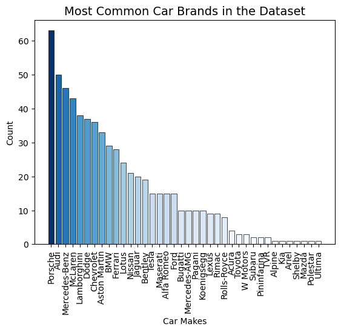

```python
# create bar chart from df created (using count and make)


plt.bar(make_freq_prop_percent["make"], make_freq_prop_percent["count"], color=colors_list_blue, edgecolor="black", linewidth=0.5)
plt.xticks(rotation=90)
plt.title("Most Common Car Brands in the Dataset", fontsize=14)
plt.xlabel("Car Makes")
plt.ylabel("Count")
plt.show()
plt.close()
```

The bar chart above shows the most common car makes in this dataset (created using the df for frequency, proportion and percent). The plot is sorted from most common to least common (left to right).

### Descriptive Statistics - `engine_type`

The engine type column is a categorical variable which includes what type of engine the car has. There are three types of engine, which are combustion, electric and hybrid. The most common engine type is a combustion engine, with a frequency count of 588. This accounts for over 92% of the cars in this dataset. Electric accounts for 7% (frequency count of 44) and hybrid accounts for less than 1% (frequency count of 4).

```python
num_unique_types = df.engine_type.nunique()
print(f"There are {num_unique_types} different types of engine")

print("\nThe unique engine types are:")
print(df.engine_type.unique())
```

```
There are 3 different types of engine

The unique engine types are:
['Combustion' 'Electric' 'Hybrid']
```

```python
# make df for frequency counts, proportion and percentage

type_counts = df.engine_type.value_counts()
type_prop = df.engine_type.value_counts(normalize=True)

type_freq_prop_percent = pd.DataFrame({
    "engine_type": type_counts.index,
    "count": type_counts.values,
    "proportion": type_prop.values
})

type_freq_prop_percent["percent"] = (type_freq_prop_percent["proportion"] * 100).round(2)

print("The value counts, proportion and percentage:")
print(type_freq_prop_percent)
```

```
The value counts, proportion and percentage:
  engine_type  count  proportion  percent
0  Combustion    588    0.924528    92.45
1    Electric     44    0.069182     6.92
2      Hybrid      4    0.006289     0.63
```

```python
# calculate mode
type_mode = type_freq_prop_percent.loc[0]["engine_type"]

print(f"The mode is: {type_mode}")
```

```
The mode is: Combustion
```

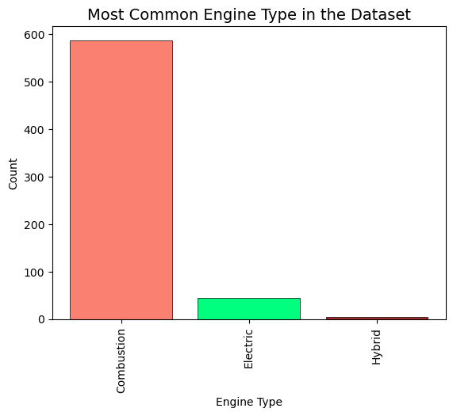

```python
# bar chart from df created (engine_type and count)


plt.bar(type_freq_prop_percent["engine_type"], type_freq_prop_percent["count"], color=["salmon", "springgreen", "brown"], edgecolor="black", linewidth=0.5)
plt.xticks(rotation=90)
plt.title("Most Common Engine Type in the Dataset", fontsize=14)
plt.xlabel("Engine Type")
plt.ylabel("Count")
plt.show()
plt.close()
```

The bar chart above shows the most to least common engine type for cars in the dataset. Clearly shows that combustion engines are significantly more common, compared with electric or hybrids.

### Descriptive Statistics - `year`

```python
# create as ordered categorical (ordered)
df['year'] = df['year'].astype('category')
df['year'] = df['year'].cat.as_ordered()

print("The data type for this column is:")
print(df.year.dtype)
```

```
The data type for this column is:
category
```

```python
num_unique_year = df.year.nunique()
print(f"There are {num_unique_year} years in the dataset")

print("\nThe unique years are:")
print(df.year.unique())

year_min = df.year.min()
year_max = df.year.max()
year_range = year_max - year_min

print(f"\nThe earlier year is {year_min} and the most recent is {year_max}, which makes the range {year_range} years")
```

```
There are 9 years in the dataset

The unique years are:
[2022, 2021, 2015, 2020, 2019, 2017, 1965, 2014, 2023]
Categories (9, int64): [1965 < 2014 < 2015 < 2017 ... 2020 < 2021 < 2022 < 2023]

The earlier year is 1965 and the most recent is 2023, which makes the range 58 years
```

```python
# make df for frequency counts, proportion and percentage

year_counts = df.year.value_counts()
year_prop = df.year.value_counts(normalize=True)

year_freq_prop_percent = pd.DataFrame({
    "year": year_counts.index,
    "count": year_counts.values,
    "proportion": year_prop.values
})

year_freq_prop_percent["percent"] = (year_freq_prop_percent["proportion"] * 100).round(2)

print("The value counts, proportion and percentage:")
print(year_freq_prop_percent)
```

```
The value counts, proportion and percentage:
   year  count  proportion  percent
0  2021    345    0.542453    54.25
1  2022    247    0.388365    38.84
2  2020     24    0.037736     3.77
3  2015      9    0.014151     1.42
4  2017      3    0.004717     0.47
5  2019      3    0.004717     0.47
6  2023      3    0.004717     0.47
7  1965      1    0.001572     0.16
8  2014      1    0.001572     0.16
```

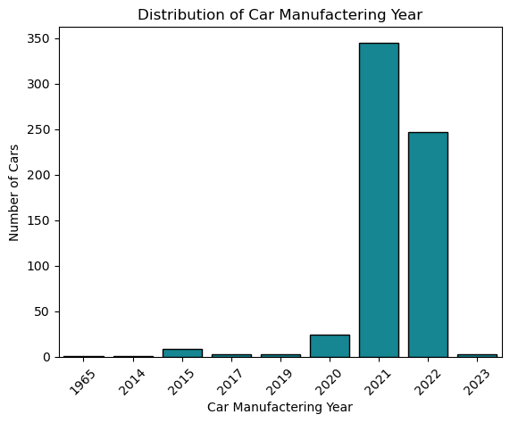

```python
# chart of distribution year
sns.countplot(data=df, x="year", color="#0097A7", edgecolor="black")
plt.title("Distribution of Car Manufactering Year")
plt.xlabel("Car Manufactering Year")
plt.ylabel("Number of Cars")
plt.xticks(rotation=45)
plt.show()
```

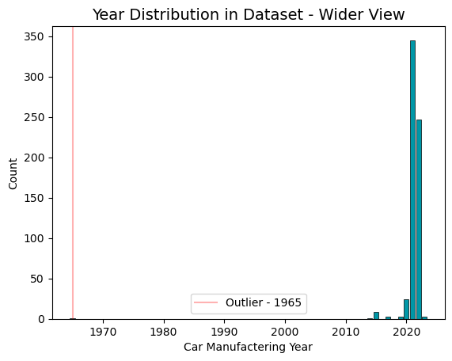

```python
plt.bar(year_freq_prop_percent["year"], year_freq_prop_percent["count"], color="#0097A7", edgecolor="black", linewidth=0.5)
plt.title("Year Distribution in Dataset - Wider View", fontsize=14)
plt.xlabel("Car Manufactering Year")
plt.ylabel("Count")
plt.axvline(1965, color="red", alpha=0.3, label="Outlier - 1965")
plt.legend()
plt.show()
plt.close()
```

The first chart (top - count chart) represents the frequency count for each year in the dataset. It is organised with more recent to the right and least recent to the left. I can clearly see that the cars are more recent, with the vast majority being manufactered in 2021 or 2022. The second chart (bottom - bar plot) represents the distribution on a larger scale, showing just how much of a gap there is between the first manufacter year (1965) and the rest (after 2014).

## Numerical Variables

Next I will calculate the descriptive statistics for the numerical variables: 'numeric_engine_size', 'horsepower', 'torque', 'zero_to_sixty' and price columns ('price_gbp' and 'price_usd').  
For each of the numerical variables I will perform the following:

- Calculate the central tendency (mean & median) and spread (SD, range, IQR).
- Calculate the maximum and minimum values.
- Visualise the IQR range using a boxplot
- Visualise the data distribution using a histogram (continuous).

### Creating Descriptive Statistics Table for Numeric Data

I will first create a summary table containing all of the descriptive statistics for all numeric variables in this dataset. I will identify the numeric columns using `select_dtypes()` and then create a DataFrame which calculates the mean, median, max, min, interquartile range (IQR), range and standard deviation for our dataset. This is similar to using `describe()` but includes the IQR and range in the DataFrame. After this, I will go through each numeric column individually, write a short summary and visualise the distribution (histogram) and range/ interquartile range (boxplot).

```python
# selects numeric columns
numeric_df = df[[
    "numeric_engine_size",
    "horsepower",
    "torque_lb",
    "zero_to_sixty",
    "price_usd",
    "price_gbp"
]]

# calculates the IQR
def iqr(x):
    return x.quantile(0.75) - x.quantile(0.25)

# creates the summary table
summary_table = pd.DataFrame({
    "mean": numeric_df.mean(),
    "median": numeric_df.median(),
    "max": numeric_df.max(),
    "min": numeric_df.min(),
    "IQR": numeric_df.apply(iqr),
    "range": numeric_df.max() - numeric_df.min(),
    "std_dev": numeric_df.std()
})

# displays the table
print(summary_table.T.round(2))
```

```
         numeric_engine_size  horsepower  torque_lb  zero_to_sixty  \
mean                    4.45      626.61     548.23           3.55
median                  4.00      591.00     507.00           3.50
max                     8.40     2000.00    1732.00           6.50
min                     1.50      181.00     151.00           1.80
IQR                     2.50      261.00     221.00           1.00
range                   6.90     1819.00    1581.00           4.70
std_dev                 1.43      307.91     251.46           0.78

          price_usd   price_gbp
mean      382198.41   298114.76
median    124845.00    97379.10
max      5200000.00  4056000.00
min        25000.00    19500.00
IQR       154528.75   120532.42
range    5175000.00  4036500.00
std_dev   769056.85   599864.34
```

### Creating Functions for Boxplots and Histograms for Numeric Columns

I have created two functions: `hist_numeric` and `boxplot_numeric`.  
The `hist_numeric` function takes the `df` and `column_name` as inputs, and creates a histogram displaying the distribution of the numeric column. It will also display the mean value of the data (with a red line), be titled "Histogram of the Distribution of *column_name*" and have approrpiately labelled x and y axis.  
The `boxplot_numeric` function takes the `df` and `column_name` as inputs, and creates a boxplot displaying the distribution of the numeric column. It will be titled "Boxplot of the Distribution of *column_name*" and have appripropriately labelled x and y axis.  
Both of these functions will be used on each numeric column to visually summarise the data, as well as the descriptive statistic table created above being used for a written summary.

```python
# function which creates histogram for numeric variables - takes df and column name as input


def hist_numeric(df, column_name):
    title_xlabel = column_name.replace("_", " ").title()
    mean = df[column_name].mean()
    median = df[column_name].median()
    plt.hist(df[column_name], color="lightgrey", edgecolor="black")
    plt.title(f"Histogram of the Distribution of {title_xlabel}",  fontsize=14)
    plt.axvline(mean, color="red", label=f"Mean ({mean:.2f})")
    plt.axvline(median, color="green", label=f"Median ({median:.2f})")
    plt.xlabel(title_xlabel)
    plt.ylabel("Count")
    plt.legend()
    plt.show()
```

```python
# function which creates boxplots for numeric variables - takes df and column name as input

def boxplot_numeric(df, column_name):
    title_ylabel = column_name.replace("_", " ").title()
    plt.boxplot(df[column_name].dropna(), patch_artist=True,
    boxprops=dict(facecolor="#DCE6F1", edgecolor="black"))
    plt.title(f"Box Plot of the Distribution of {title_ylabel}", fontsize=14)
    plt.xticks([])
    plt.ylabel(title_ylabel)
    plt.tight_layout()
    plt.show()
```

### Descriptive Statistics - `numeric_engine_size`

I started with the `numeric_engine_size` column, which tells us in liters (L) the size of each car engine. There is a lot of missing data in this column (48 missing values), but as explained earlier it is missing not at random (MNAR), due to electric cars not having an engine size.

**Descriptive Statistics**

```python
print("Missing data:")
print(df.numeric_engine_size.isna().sum())

print("\nSummary table:")
print(summary_table.T.round(2)["numeric_engine_size"])

# max and min
print("\nMax value:")
print(df[["make", "model"]][df["numeric_engine_size"] == df.numeric_engine_size.max()])

print("\nMin value:")
print(df[["make", "model"]][df["numeric_engine_size"] == df.numeric_engine_size.min()])
```

```
Missing data:
48

Summary table:
mean       4.45
median     4.00
max        8.40
min        1.50
IQR        2.50
range      6.90
std_dev    1.43
Name: numeric_engine_size, dtype: float64

Max value:
      make      model
138  Dodge      Viper
292  Dodge      Viper
312  Dodge  Viper ACR

Min value:
    make model
494  BMW    i8
```

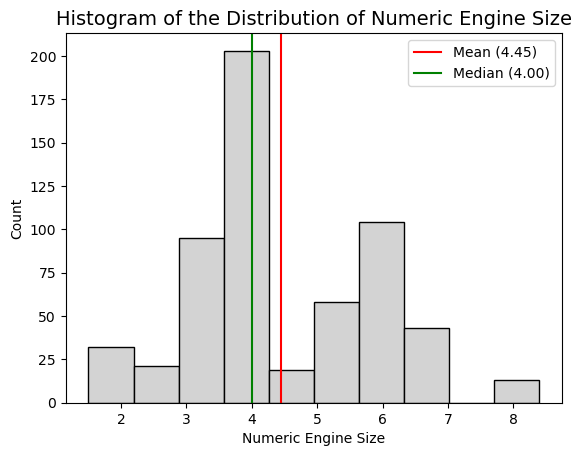

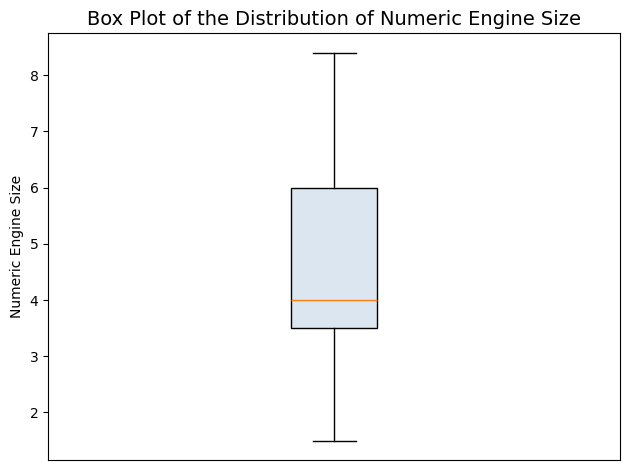

```python
hist_numeric(df, "numeric_engine_size")

boxplot_numeric(df, "numeric_engine_size")
```

## Descriptive Statistics - `horsepower`

The next column I looked at was the `horsepower`. This column tells us the power output of the car, with higher horsepower (hp) indicating higher power and performance.

**Descriptive Statistics**

- The values ranged from 181 hp (Mazda MX-5 Miata) to 2000 hp (Lotus Evija), which means that the horsepower column has a range of 1819 hp.
- The median value is 591 hp, with a mean of 626.61 hp. This suggests a slight right skewed distribution, with some very high powered cars bringing up the average.
- The interquartile range is 261 hp
- The standard deviation is 307 hp, which suggests that most values in the data fall within 307 hp of the mean (about 300 hp - 950 hp).
- The histogram shows a cluster of cars around 450 - 700 hp, with only a few higher powered cars on the right hand side. This reinforces the idea of a right hand skew, which was determined from the mean-median difference.
- The boxplot shows that the middle 50% falls roughly between 450 hp and 700 hp, with the median being close to the middle of the IQR box. There are a number of outliers on the upper end of the scale, which further supports the theory that there are a number of high powered cars which have affected the average.

```python
print("\nSummary table:")
print(summary_table.T.round(2)["horsepower"])


print("Max value:")
print(df[["make", "model"]][df["horsepower"] == df.horsepower.max()])

print("Min value:")
print(df[["make", "model"]][df["horsepower"] == df.horsepower.min()])
```

```
Summary table:
mean        626.61
median      591.00
max        2000.00
min         181.00
IQR         261.00
range      1819.00
std_dev     307.91
Name: horsepower, dtype: float64
Max value:
      make  model
581  Lotus  Evija
Min value:
     make       model
89  Mazda  MX-5 Miata
```

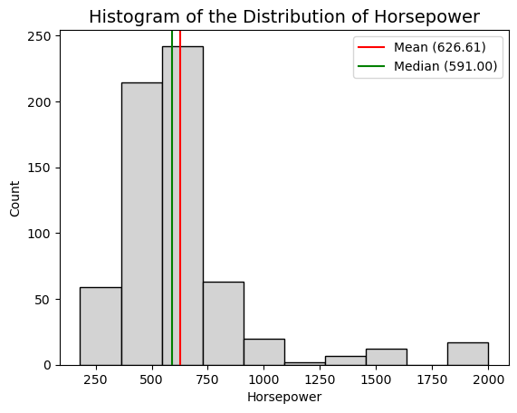

```
None
```

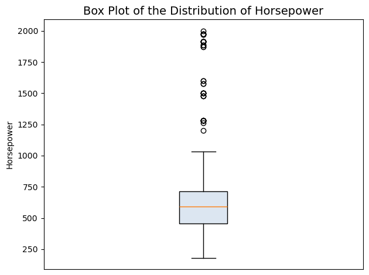

```
None
```

```python
print(hist_numeric(df, "horsepower"))

print(boxplot_numeric(df, "horsepower"))
```

### Descriptive Statistics - `torque_lb`

The next column I will look at is the `torque_lb`, which is the rotational force of the vehicle in pounds-feet (lb-ft). Generally a higher torque is associated with higher power and performance in a car.

**Descriptive Statistics**

- The values range from 151 lb-ft (Mazda MX-5 Miata) and 1732 lb-ft (Rimac C_Two) which makes the range 1581 lb-ft.
- The median value is 507 lb-ft, with the mean being 548.23 lb-ft. This suggests that there is a slight right skew in the data, with some high power cars bringing up the average.
- The interquartile range is 221 lb-ft.
- The standard deviation is 251 lb-ft, which means that most of the data falls ± 250 of the mean value (about 300 - 800 lb-ft).
- The histogram shows most of the data clusters around 400 - 600 lb-ft, with only very few towards the higher end of the scale. This supports the theory that the data is right skewed due to some higher powered cars bringing the average up (from the mean-median difference).
- The boxplot shows that the middle 50% of the data falls roughly between 400 and 650 lb-ft. The median is equal distance from both the upper and lower quartiles. There are some outliers towards the upper end of the scale, which further supports the theory of some high powered cars brining up the average torque value.

```python
print("\nSummary table:")
print(summary_table.T.round(2)["torque_lb"])


print("\nMax value:")
print(df[["make", "model"]][df["torque_lb"] == df.torque_lb.max()])

print("\nMin value:")
print(df[["make", "model"]][df["torque_lb"] == df.torque_lb.min()])
```

```
Summary table:
mean        548.23
median      507.00
max        1732.00
min         151.00
IQR         221.00
range      1581.00
std_dev     251.46
Name: torque_lb, dtype: float64

Max value:
      make  model
225  Rimac  C_Two
337  Rimac  C_Two

Min value:
     make       model
89  Mazda  MX-5 Miata
```

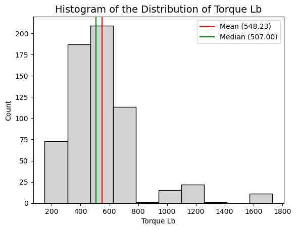

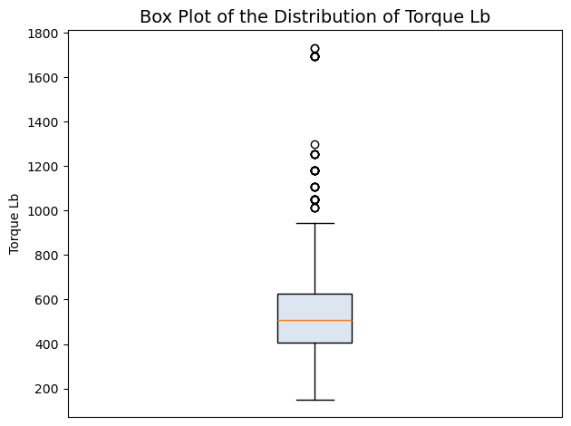

```python
hist_numeric(df, "torque_lb")

boxplot_numeric(df, "torque_lb")
```

### Descriptive Statistics - `zero_to_sixty`

The next column I looked at was the `zero_to_sixty` column, which tells us in seconds how quickly a car can go from 0-60 mph. It is a measure of how quick a car can accelerate from a standstill, and a lower 0-60 accelaration time generally indicates a higher performance car.  
**Descriptive Statistics**

- The slowest 0-60 acceleration was 6.50 seconds (Mazda MX-5 Miata), and the fastest was 1.80 seconds (Rimac C_Two). This gives an overall range of 4.70 seconds.
- The median value was 3.50 seconds, while the mean was 3.55 seconds. There is only a very minimal difference between the two, suggesting that the distribution is relatively symmetrical.
- The interquartile range is 1.00 seconds.
- The standard deviation is only 0.78 seconds, which means the values are very closely clustered around the mean (around 2.70 - 4.20 seconds).
- The histplot shows the data is quite symmetrical, clustered around the mean of 3.55 seconds. Although, there are some slower cars to the right hand side which may explain the very slightly higher mean (compared to median).
- The boxplot shows that the middle 50% of the data falls within 3 to 4 seconds. The median is exactly in the middle of these two points at 3.50. There is two outliers towards the upper end (both with 0-60 taking over 6 seconds).

```python
print("\nSummary table:")
print(summary_table.T.round(2)["zero_to_sixty"])


print("\nMax value:")
print(df[["make", "model"]][df["zero_to_sixty"] == df.zero_to_sixty.max()])

print("\nMin value:")
print(df[["make", "model"]][df["zero_to_sixty"] == df.zero_to_sixty.min()])
```

```
Summary table:
mean       3.55
median     3.50
max        6.50
min        1.80
IQR        1.00
range      4.70
std_dev    0.78
Name: zero_to_sixty, dtype: float64

Max value:
     make       model
89  Mazda  MX-5 Miata

Min value:
      make  model
303  Rimac  C_Two
337  Rimac  C_Two
```

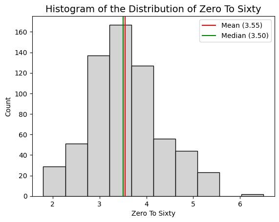

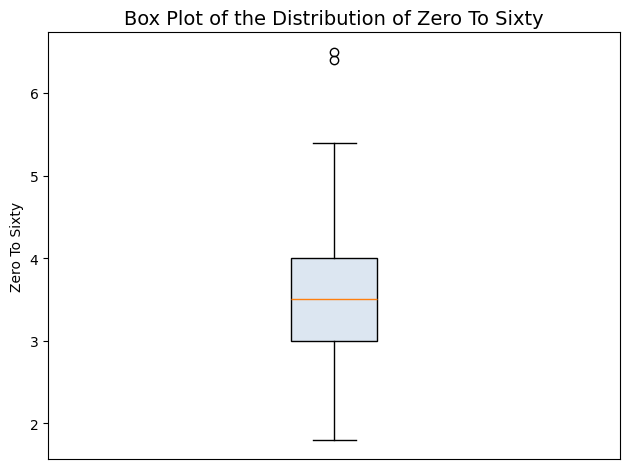

```python
hist_numeric(df, "zero_to_sixty")

boxplot_numeric(df, "zero_to_sixty")
```

### Descriptive Statistics - `price_gbp`

The last column I will look at for single variable summary statistics is `price_gbp`. This column represents the price of the car in British Pounds (GBP).

**Descriptive Statistics**

- The values range from £19,500 (Chevrolet Camero) to nearly £4.1 Million (Bugatti Chiron Super Sport), which makes the range just over £4 Million.
- The median value is £97k, with a mean value of nearly £298K. The mean value is significantly greater than the median value, which suggests the data will be heavily right skewed, with very expensive cars (like the Bugatti Chiron) bringing the average up.
- The interquartile range is £120K.
- The standard deviation is 600K, suggesting that there is a large variation in the prices of sports cars in the data set, with data falling within £600k of the mean. As the data is significantly right skewed, the standard deviation and mean aren't the best measures of central tendency and spread (impacted by significant outliers).
- The histogram shows a cluster around the mean and median, but there are some expensive cars which bring the mean up (some cars being over £4 million).
- The boxplot shows the middle 50% of the data falls between 55K and 176K, which is a much better estimate of spread (compared to SD - skewed by outliers). The box plot shows a significant number of outliers towards the top of the scale, which explains why the mean is greater than the median.

```python
print("\nSummary table:")
print(summary_table.T.round(2)["price_gbp"])


print("\nMax value:")
print(df[["make", "model", "year"]][df["price_gbp"] == df.price_gbp.max()])

print("\nMin value:")
print(df[["make", "model", "year"]][df["price_gbp"] == df.price_gbp.min()])
```

```
Summary table:
mean        298114.76
median       97379.10
max        4056000.00
min          19500.00
IQR         120532.42
range      4036500.00
std_dev     599864.34
Name: price_gbp, dtype: float64

Max value:
        make                    model  year
404  Bugatti  Chiron Super Sport 300+  2022
553  Bugatti  Chiron Super Sport 300+  2021

Min value:
          make   model  year
434  Chevrolet  Camaro  2021
586  Chevrolet  Camaro  2022
```

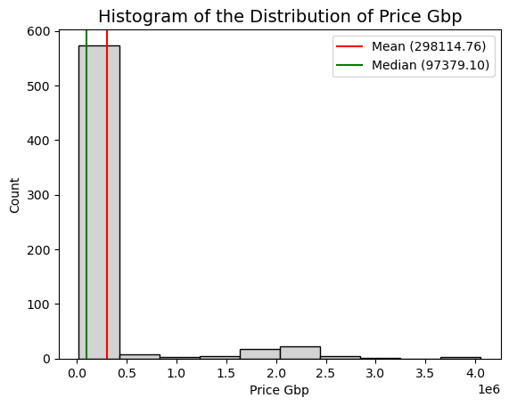

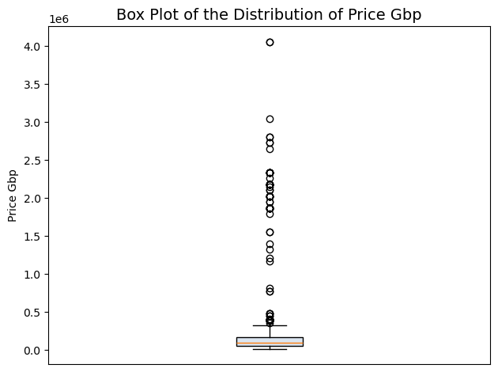

```python
hist_numeric(df, "price_gbp")

boxplot_numeric(df, "price_gbp")
```

## Grouping by Categories

Now that I have looked at the descriptive statistics for individual categorical and numerical variables, and also considered that relationships between each numerical variable (correlations, scatterplots). I will look at visualising relationships between a categorical variable and a numeric variable (e.g. average horesepower for each type of engine, average price of cars per make).

### Creating Bar chart function

First I created a function which took `df` and `cat_col` as inputs and did the following:

- Created a 2 X 3 subplot figure and set `plot_idx` to 0.
- Iterated through a list (`column_list`) which contained the numeric column names.
- It then created the title, x label and y label using the `cat_col` and the column names from the list. Also increased the `plot_idx` by one (moves onto next plot), and added a horizontal line to show overall mean.
- `make` - grouped by the make (used if statement to determine) and plotted the data on a bar chart (within this it created an "Other" column for makes with a value count of less than 10).
- `engine_type` and `year` - grouped by engine type or year (used elif statement) and plotted the data on a bar chart.
- Hid any empty subplots (as some categories had more than others i.e. `engine_type` - excluded engine size as hybrid and electric engines didn't have a numeric size - just large bar for combustion).
- displayed the plot and tidied using `tight_layout()`.

```python
def barchart(df, cat_col):

    column_list = ["horsepower", "torque_lb", "zero_to_sixty", "price_gbp", "numeric_engine_size"]

    # creates the subplot - fig etc
    grid_cols = 2
    grid_rows = 3

    fig, axes = plt.subplots(grid_rows, grid_cols, figsize=(5*grid_cols, 5*grid_rows))

    axes = axes.flatten()

    plot_idx = 0

    # iterates through list, creates title and labels axis
    for col in column_list:
        if cat_col == "engine_type" and col == "numeric_engine_size":
            continue
        x = cat_col.replace("_", " ").title()
        y = col.replace("_", " ").title()
        ax = axes[plot_idx]
        ax.set_title(f"Bar Chart of the Average {y} \n Grouped by {x}")
        ax.set_xlabel(x)
        ax.set_ylabel(y)
        plot_idx += 1
        ax.axhline(y=df[col].mean(), color='red', linestyle='--', linewidth=1.5, label=f"Overall Mean: {df[col].mean():.2f}")


        # make plots
        if cat_col == "make":
            new_df = df[cat_col].value_counts().reset_index()
            new_df.columns = [cat_col, "count"]
            new_df["mask"] = new_df.apply(lambda row: row[cat_col] if row["count"] > 10 else "Other", axis=1)
            group_df = df.groupby(cat_col)[col].mean().reset_index()
            merged_df = pd.merge(new_df, group_df, on=cat_col)
            ax.bar(merged_df["mask"], merged_df[col])
            ax.tick_params(axis='x', labelrotation=90)
            ax.legend()

        elif (cat_col == "year") | (cat_col == "engine_type"):
            group_df = df.groupby(cat_col, observed=True)[col].mean().reset_index()
            ax.bar(group_df[cat_col], group_df[col])
            ax.legend()

    # hides missing plots
    for ax in axes[plot_idx:]:
        ax.set_visible(False)

    plt.tight_layout()
    plt.show()
```

### Grouping by Year

The first categorical variable I will group by is the year. I have treated the `year` column like a categorical variable, and have therefore grouped the data by year (i.e. calculates mean for 1965, 2022, 2023 etc). I used the function created above to display the data in a bar chart.

```python
grouped_year = df.groupby("year", observed=True)[["horsepower", "torque_lb", "zero_to_sixty", "price_gbp", "numeric_engine_size"]].mean()

print(grouped_year.round(2))

print("\n2020 cars - model, make, hp, torque and 0-60")
print(df[["make", "model", "horsepower", "torque_lb", "zero_to_sixty"]][df["year"] == 2020])

print("\n2015 - model, make and price")
print(df[["make", "model", "price_gbp"]][df["year"] == 2015])

print("\n2017 - model, make and engine size")
print(df[["make", "model", "numeric_engine_size"]][df["year"] == 2017])
```

```
      horsepower  torque_lb  zero_to_sixty  price_gbp  numeric_engine_size
year
1965      435.00     440.00           4.20  780000.00                 7.00
2014      622.00     468.00           3.50  214500.00                 6.20
2015      664.67     548.78           3.31  584537.20                 5.74
2017      645.00     600.00           3.30   94896.10                 8.40
2019      615.33     533.67           3.60  346574.80                 4.23
2020      462.08     386.17           3.91  255430.89                 3.83
2021      631.36     550.69           3.49  302868.75                 4.65
2022      634.70     560.58           3.61  288047.28                 4.11
2023      675.00     579.00           2.83   84500.00                 4.25

2020 cars - model, make, hp, torque and 0-60
              make          model  horsepower  torque_lb  zero_to_sixty
42             BMW             i8         369      420.0            4.2
```

[output cut: 41 more lines]

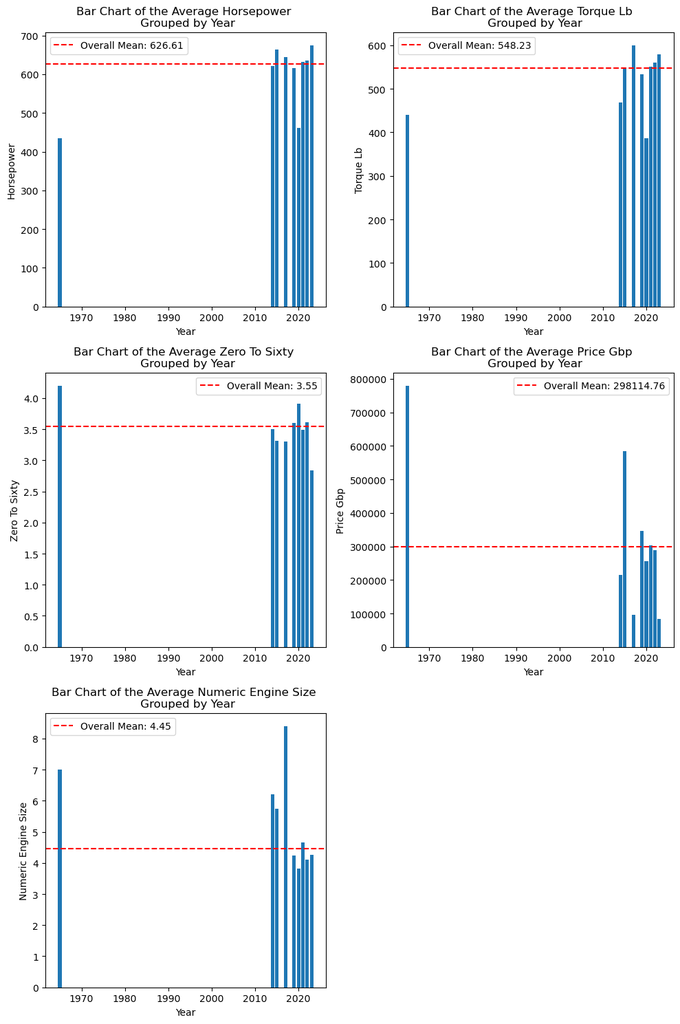

```
None
```

```python
print(barchart(df, "year"))
```

### Grouping by Engine Type

Next I grouped the data by engine type (combustion, electric and hybrid). I used the function (created above) to plot group and plot the data on bar charts. For the engine type category I excluded the `numeric_engine_size` column, as the only cars with a value for this column were combustion engines (i.e. there would only be one bar - plotting overall average).

**Summary**  
The general trend is that electric cars are superior in power output (torque, horsepower) and performance (0-60 time), compared to traditional combustion cars or hybrids. However, they are significantly more expensive than the other types of car.

```python
grouped_type = df.groupby("engine_type", observed=True)[["horsepower", "torque_lb", "zero_to_sixty", "price_gbp"]].mean()

print(grouped_year.round(2))
```

```
      horsepower  torque_lb  zero_to_sixty  price_gbp  numeric_engine_size
year
1965      435.00     440.00           4.20  780000.00                 7.00
2014      622.00     468.00           3.50  214500.00                 6.20
2015      664.67     548.78           3.31  584537.20                 5.74
2017      645.00     600.00           3.30   94896.10                 8.40
2019      615.33     533.67           3.60  346574.80                 4.23
2020      462.08     386.17           3.91  255430.89                 3.83
2021      631.36     550.69           3.49  302868.75                 4.65
2022      634.70     560.58           3.61  288047.28                 4.11
2023      675.00     579.00           2.83   84500.00                 4.25
```

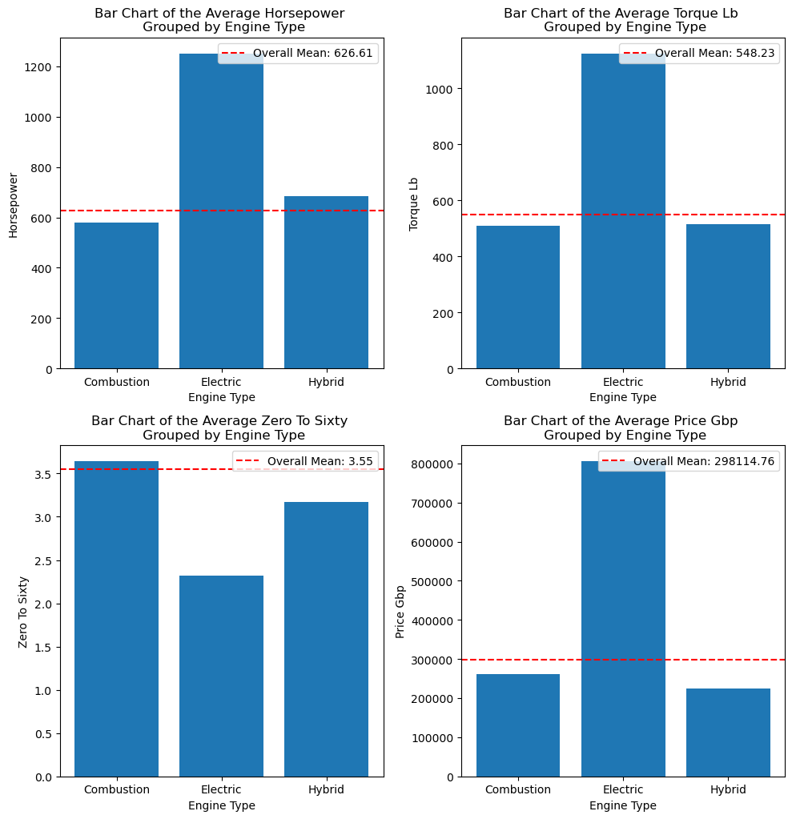

```
None
```

```python
print(barchart(df, "engine_type"))
```

```python
# function to view top or bottom in a list (average - by make) i.e. calculates average for each make, returns a sorted list

def top_bottom_five(df, position, numeric_col, num):
    print("\n" + str(position.title()) + " " + str(num) + " cars based on " + str(numeric_col))
    grouped_make = df.groupby("make", observed=True)[numeric_col].mean().reset_index()
    sorted = grouped_make.sort_values(numeric_col).round(2)

    if position == "top":
        return sorted.tail(int(num))
    if position == "bottom":
        return sorted.head(int(num))
```

### Grouping by Make

The last grouping category was the make. As there were a large number of car makes/ brands, I grouped less common car makes in an `Other` column (i.e. less than 10 in each group). I used the function (created earlier) to group and plot the data on bar charts.

**Summary**  
The highest power output (hp and torque) and performance (0-60 acceleration time) for cars are generally found in the low-volume ultra-performance brands, like Rimac, Pininfarina and Bugatti. The largest engine size is also found in some of these ultra-high performance cars like the Bugatti, but is also found in classic cars like the Shelby Cobra. These ultra-performance sports car brands are associated with much more expensive cars, which makes sense as they are the highest performance, limited edition, luxuary sports cars. :

```python
# horsepower
print(top_bottom_five(df, "top", "horsepower", 5))

print(top_bottom_five(df, "bottom", "horsepower", 5))


# torque
print(top_bottom_five(df, "top", "torque_lb", 5))

print(top_bottom_five(df, "bottom", "torque_lb", 5))


# zero to sixty
print(top_bottom_five(df, "top", "zero_to_sixty", 5))

print(top_bottom_five(df, "bottom", "zero_to_sixty", 5))

# price
print(top_bottom_five(df, "top", "price_gbp", 5))

print(top_bottom_five(df, "bottom", "price_gbp", 5))

# numeric engine size
print(top_bottom_five(df, "top", "numeric_engine_size", 5))

print(top_bottom_five(df, "bottom", "numeric_engine_size", 5))
```

```
Top 5 cars based on horsepower
           make  horsepower
36       Ultima     1200.00
15   Koenigsegg     1342.20
8       Bugatti     1509.30
26  Pininfarina     1873.00
29        Rimac     1908.22

Bottom 5 cars based on horsepower
      make  horsepower
20   Mazda       181.0
2   Alpine       288.0
32  Subaru       310.0
3    Ariel       320.0
24  Nissan       360.0

Top 5 cars based on torque_lb
           make  torque_lb
15   Koenigsegg     1069.6
8       Bugatti     1180.0
36       Ultima     1300.0
26  Pininfarina     1696.0
29        Rimac     1704.0

Bottom 5 cars based on torque_lb
      make  torque_lb
20   Mazda     151.00
2   Alpine     236.00
3    Ariel     243.00
24  Nissan     287.86
32  Subaru     290.00

Top 5 cars based on zero_to_sixty
      make  zero_to_sixty
13  Jaguar           4.62
14     Kia           4.70
24  Nissan           4.74
32  Subaru           4.90
20   Mazda           6.50

```

[output cut: 24 more lines]

```
Top 5 cars based on numeric_engine_size
           make  numeric_engine_size
31       Shelby                  7.0
8       Bugatti                  8.0
26  Pininfarina                  NaN
29        Rimac                  NaN
34        Tesla                  NaN

Bottom 5 cars based on numeric_engine_size
        make  numeric_engine_size
2     Alpine                  1.8
3      Ariel                  2.0
27  Polestar                  2.0
20     Mazda                  2.0
32    Subaru                  2.5
```

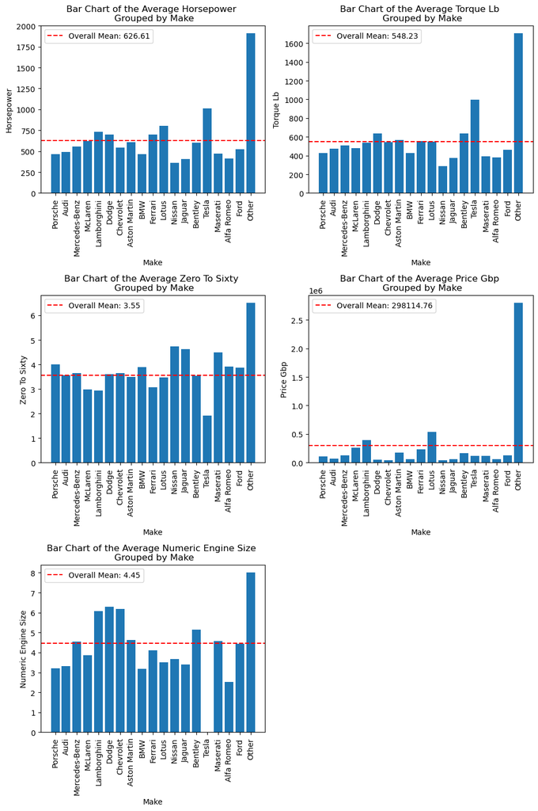

```
None
```

```python
print(barchart(df, "make"))
```

## Relationship between Numeric Variables

The next step is to look at the relationship between numeric variables. To do this I will look at the correlation (Pearson r) between each numeric variable, and plot the relationship on a scatter plot.  
Below is a correlation matrix, showing the relationship between each numeric variable.

```python
corr_df = df[['horsepower',
              'torque_lb',
              'price_gbp',
              'zero_to_sixty',
              'numeric_engine_size']]

corr_matrix = corr_df.corr()
corr_matrix
```

|  | horsepower | torque_lb | price_gbp | zero_to_sixty | numeric_engine_size |
| --- | --- | --- | --- | --- | --- |
| horsepower | 1.000000 | 0.943328 | 0.757179 | -0.732867 | 0.613739 |
| torque_lb | 0.943328 | 1.000000 | 0.695995 | -0.717640 | 0.594897 |
| price_gbp | 0.757179 | 0.695995 | 1.000000 | -0.486955 | 0.355251 |
| zero_to_sixty | -0.732867 | -0.717640 | -0.486955 | 1.000000 | -0.416005 |
| numeric_engine_size | 0.613739 | 0.594897 | 0.355251 | -0.416005 | 1.000000 |

### `horsepower`

- Horsepower X Torque: there is a very strong positive correlation between hp and torque (0.94), which means that as hp increases so does the motor torque.
- Horsepower X Price: there is a very strong positive correlation between hp and price (0.76), which means as hp increases the price increases.
- Horsepower X Zero to Sixty: there is a very strong negative correlation between hp and 0-60 (-0.73), which means that as hp increases, the 0-60 acceleration time decreases.
- Horsepower X engine size: there is a strong positive correlation between hp and engine size (0.61), which means that as hp increases so does the engine size, but less effect than other variables.

To summarise, there are very strong positive correlations between hp X torque and hp X price. There is a very strong negative correalation between hp X 0-60 time. And also a strong correlation between hp X engine size (less so than others).

### `zero_to_sixty`

To summarize, strong negative correlation between 0-60 X torque and 0-60 X hp, moderate negative correlations between 0-60 time X price and 0-60 time X engine size.

### `numeric_engine_size`

To summarise, there is a strong positive correlation between engine size X horsepower, moderate positive between engine size X torque and a weak positive between engine size X price. Moderate negative correlation between engine size and 0-60 time.

### Overall summary

All the numerical variables in the data are highly correlated with one another. The strongest correlation being between horsepower and torque (0.94), which is to be expected as both of these are measures of power output. It is also clear that these two measures of power output are associated with vehicle performance, as both are strongly associated with better acceleration (associated with lower 0-60 times). Higher power output and performance (0-60 time) is also associated with a higher price, which is again, to be expected. The variable that was least associated with the others was the engine size, with correlations being moderate-weak for most aspects. Shows that engine size may not be the best measure to determine or predict a cars performance (especially as it only includes combustion engines - electric cars do have quite high hp and torque).  
There are a number of scatterplots shown below which visualise the relationships between all of these variables:

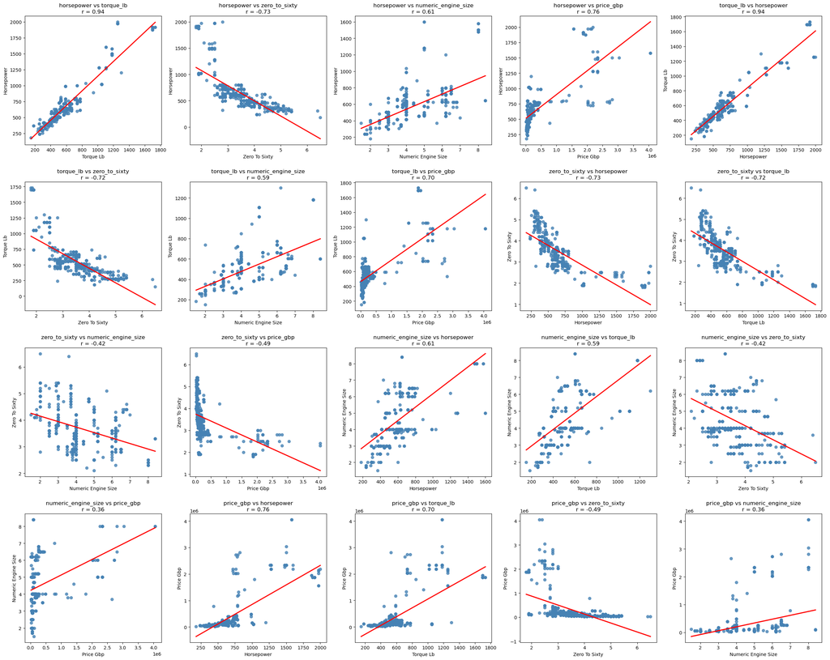

```python
def scatterplot(df, column_list):

    # total plots
    n = len(column_list) ** 2

    # number of columns in figure grid
    grid_cols = 5
    grid_rows = 4

    fig, axes = plt.subplots(grid_rows, grid_cols, figsize=(5*grid_cols, 5*grid_rows))


    axes = axes.flatten()

    plot_idx = 0

    for y_col in column_list:
        for x_col in column_list:
            if x_col == y_col:
                continue
            else:


                ax = axes[plot_idx]

                correlation = df[x_col].corr(df[y_col])

                sns.regplot(x=df[x_col], y=df[y_col], scatter_kws={"color": "steelblue"}, line_kws={"color": "red"}, ci=None, ax=ax)

                ax.set_xlabel(x_col.replace("_", " ").title())
                ax.set_ylabel(y_col.replace("_", " ").title())
                ax.set_title(f"{y_col} vs {x_col}\nr = {correlation:.2f}")

                plot_idx += 1

    plt.tight_layout()
    plt.show()




scatterplot(df, ["horsepower", "torque_lb", "zero_to_sixty", "numeric_engine_size", "price_gbp"])
```

## Key Findings

- Found that on average, electric vehicles are higher in performance (0-60 time) and power (horsepower and torque), however they are usually more expensive.
- Found that the most powerful (horsepower and torque), high performance (0-60 time) and expensive cars comes from low-volume car brands like Rimac, Bugatti and Koenigsegg.
- Also found that cars in general are getting more powerful, with a higher acceleration performance, however the engine size does seem to be decreasing (suggests more efficient ways of creating powerful cars).
- The performance and power of a car are highly correlated with one another, as well as with other aspects like price and engine size. i.e. more powerful cars are typically more expensive and generally have larger engines. However, this data is correlational and so no cause can be inferred from it (i.e. I couldn't say that it is the higher horsepower of a car which causes it to be more expensive - could be the other way round, or due to another factor entirely).